# Raport 2

Michal Burdukiewicz, Piotr Sobczyk

10 czerwca 2015

# Porównanie istotnych n-gramów z Gasior2014 i analiz biogram

n-gramy z Gasior2014, które pojawiają się w analizie n-gram

|  | ngram | target0 | target1 | ftarget0 | ftarget1 | decoded |
| --- | --- | --- | --- | --- | --- | --- |
| 44 | g.v_0 | 23 | 32 | 0.00 | 0.01 | gv |
| 76 | f.l_1 | 8 | 24 | 0.00 | 0.01 | f_l |
| 93 | s.v_1 | 32 | 32 | 0.01 | 0.01 | s_v |
| 108 | i.i_2 | 20 | 36 | 0.00 | 0.01 | i__i |
| 109 | s.i_2 | 6 | 17 | 0.00 | 0.01 | s__i |
| 128 | l.y_2 | 2 | 11 | 0.00 | 0.00 | l__y |
| 141 | s.i_3 | 6 | 17 | 0.00 | 0.01 | s___i |

n-gramy z gasior2014, które się nie pojawiają w tabeli: s.f_0, y.n_1, t.v_1, y.y_2, v.i_2, l.i_2, n.y_2, y.q_3, r.r_3, t.i_3, v.i_3, l.i_3, l.v_3, i.i_3, i.f_3, y.r_3, y.i_3.

# Generowanie kodowań aminokwasów

## Cechy wybrane do badań

Cechy wykorzystane do tworzenia kodowań - parametr size.

|  | Property |
| --- | --- |
| 1 | P30 Size (Dawson, 1972) In “The Biochemical Genetics of Man” (Brock, D.J.H. and Mayo, O., |
| 2 | P36 Molecular weight (Fasman, 1976) “Handbook of Biochemistry and Molecular Biology”, 3rd ed., Proteins - |
| 3 | P54 Volume (Grantham, 1974) Amino acid difference formula to help explain protein evolution Science 185, 862-864 (1974) |

Cechy wykorzystane do tworzenia kodowań - parametr hydroph.

|  | Property |
| --- | --- |
| 1 | P1 Hydrophobicity index (Argos et al., 1982) Structural prediction of membrane-bound proteins Eur. J. Biochem. 128, 565-575 (1982) |
| 2 | P26 Normalized average hydrophobicity scales (Cid et al., 1992) Hydrophobicity and structural classes in proteins Protein Engineering 5, 373-375 (1992) |
| 3 | P33 Consensus normalized hydrophobicity scale (Eisenberg, 1984) Three-dimensional structure of membrane and surface proteins Ann. Rev. Biochem. 53, 595-623 (1984) |
| 4 | P57 Hydrophilicity value (Hopp-Woods, 1981) Prediction of protein antigenic determinants from amino acid sequecces Proc. Natl. Acad. Sci. USA 78, 3824-3828 (1981) |

Cechy wykorzystane do tworzenia kodowań - parametr solvent.

|  | Property |
| --- | --- |
| 1 | P19 Residue accessible surface area in folded protein (Chothia, 1976) The nature of the accessible and buried surfaces in proteins J. Mol. Biol. 105, 1-14 (1976) |
| 2 | P65 Average accessible surface area (Janin et al., 1978) Conformation of amino acid side-chains in proteins J. Mol. Biol. 125, 357-386 (1978) |
| 3 | P199 Hydration potential (Wolfenden et al., 1981) Affinties of amino acid side chains for solvent water Biochemistry 20, 849-855 (1981) |

## Zróżnicowanie międzyaminokwasowe wybranych cech

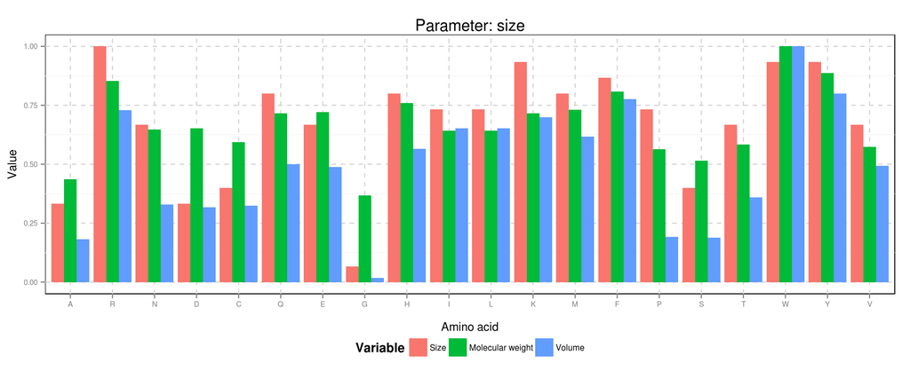

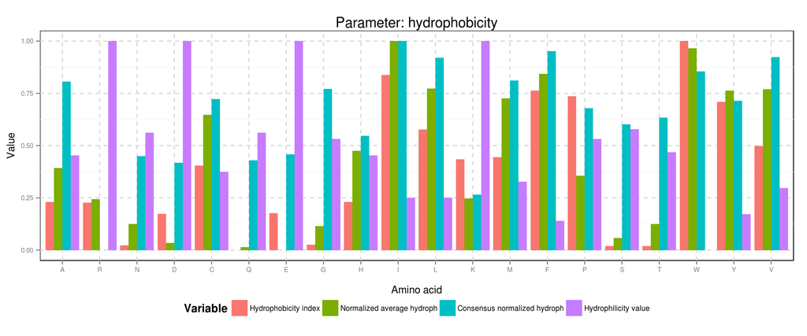

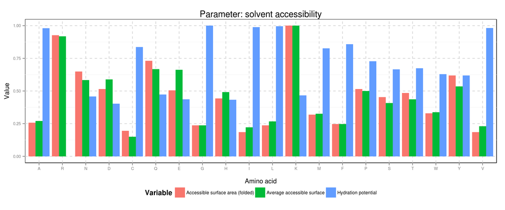

## Sposób tworzenia kodowań.

1. Z bazy AAIndex (release 10_2013) wybrano 10 cech reprezentujących różne właściwości aminokwasów: wielkość, hydrofobowość i dostępność dla rozpuszczalnika.
2. Cechy znormalizowano między 0 i 1.
3. Wszystkie możliwe kombinacje tych cech (1 jedna z każdego rodzaju) zgrupowano (dystans euklidesowski, metoda “complete”).
4. Każde zgrupowanie podzielono na 3, 4 i 5 grup.

Wszystkie kombinacje cech.

|  | size | hydroph | solvent |
| --- | --- | --- | --- |
| 1 | P30 | P1 | P19 |
| 2 | P36 | P1 | P19 |
| 3 | P54 | P1 | P19 |
| 4 | P30 | P26 | P19 |
| 5 | P36 | P26 | P19 |
| 6 | P54 | P26 | P19 |
| 7 | P30 | P33 | P19 |
| 8 | P36 | P33 | P19 |
| 9 | P54 | P33 | P19 |
| 10 | P30 | P57 | P19 |
| 11 | P36 | P57 | P19 |
| 12 | P54 | P57 | P19 |
| 13 | P30 | P1 | P65 |
| 14 | P36 | P1 | P65 |
| 15 | P54 | P1 | P65 |
| 16 | P30 | P26 | P65 |
| 17 | P36 | P26 | P65 |
| 18 | P54 | P26 | P65 |
| 19 | P30 | P33 | P65 |
| 20 | P36 | P33 | P65 |
| 21 | P54 | P33 | P65 |
| 22 | P30 | P57 | P65 |
| 23 | P36 | P57 | P65 |
| 24 | P54 | P57 | P65 |
| 25 | P30 | P1 | P199 |
| 26 | P36 | P1 | P199 |
| 27 | P54 | P1 | P199 |
| 28 | P30 | P26 | P199 |
| 29 | P36 | P26 | P199 |
| 30 | P54 | P26 | P199 |
| 31 | P30 | P33 | P199 |
| 32 | P36 | P33 | P199 |
| 33 | P54 | P33 | P199 |
| 34 | P30 | P57 | P199 |
| 35 | P36 | P57 | P199 |
| 36 | P54 | P57 | P199 |

Podczas badań nie uwzględniono polarności z względu na trudności w wyskalowaniu.

# Najlepsze kodowania

Dla każdego kodowania przprowadzono 5-krotną walidację krzyżową. Walidację powtórzono 4 razy (4 z powodu ograniczeń obliczeniowych). Obliczenia zostały przeprowadzone uwzględniając dwie strategie uczenia: tylko heksamery w zbiorze uczącycm (etykiety hexamers na rysunkach i w tabelach) oraz sekwencje o dowolnej długości w zbiorze uczącym (etykieta all-mers na rysunkach i w tabelach).

## Heksamery

[figure not shown]

Na rysunku powyżej przedstawiono średnie AUC dla klasyfikatorów uczonych dla heksamerów (czerwone kropki) oraz minimalną i maksymalną wartość AUC. Wybrano 10% najlepszych kodowań.

Kodowanie 32.

|  | Group |
| --- | --- |
| 1 | A, G |
| 2 | R, K |
| 3 | N, D, Q, E, H, P, S, T |
| 4 | C, I, L, M, F, V |
| 5 | W, Y |

Kodowanie 41.

|  | Group |
| --- | --- |
| 1 | A, C, G |
| 2 | R, K |
| 3 | N, Q, E, H, P, T, Y |
| 4 | D, S |
| 5 | I, L, M, F, W, V |

Kodowanie 44.

|  | Group |
| --- | --- |
| 1 | A, C, G, S |
| 2 | R, K |
| 3 | N, Q, H, P, T |
| 4 | D, E |
| 5 | I, L, M, F, W, Y, V |

Kodowanie 53.

|  | Group |
| --- | --- |
| 1 | A, C, G |
| 2 | R, K |
| 3 | N, Q, H, P, S, T |
| 4 | D, E |
| 5 | I, L, M, F, W, Y, V |

Kodowanie 77.

|  | Group |
| --- | --- |
| 1 | A, C |
| 2 | R, K |
| 3 | N, Q, E, H, P, T |
| 4 | D, G, S |
| 5 | I, L, M, F, W, Y, V |

Kodowanie 79.

|  | Group |
| --- | --- |
| 1 | A, G |
| 2 | R, K |
| 3 | N, D, Q, E, H, P, S, T |
| 4 | C, I, L, M, F, V |
| 5 | W, Y |

Kodowanie 86.

|  | Group |
| --- | --- |
| 1 | A, C, G |
| 2 | R, K |
| 3 | N, Q, E, H, P, T, Y |
| 4 | D, S |
| 5 | I, L, M, F, W, V |

Kodowanie 89.

|  | Group |
| --- | --- |
| 1 | A, C, G, S |
| 2 | R, K |
| 3 | N, Q, H, P, T |
| 4 | D, E |
| 5 | I, L, M, F, W, Y, V |

Kodowanie 90.

|  | Group |
| --- | --- |
| 1 | A, G, P, S, T |
| 2 | R, D, E, K |
| 3 | N, Q |
| 4 | C, H, I, L, M, V |
| 5 | F, W, Y |

Kodowanie 91.

|  | Group |
| --- | --- |
| 1 | A, C, G |
| 2 | R, D, E, K |
| 3 | N, Q, H, P, S, T |
| 4 | I, L, M, V |
| 5 | F, W, Y |

Kodowanie 92.

|  | Group |
| --- | --- |
| 1 | A, C, G, P, S, T |
| 2 | R, D, E, K |
| 3 | N, Q, H |
| 4 | I, L, M, V |
| 5 | F, W, Y |

Wszystkie najlepsze kodowania zawierają 5 grup.

Zliczenie cech wykorzystywanych przez najlepsze kodowania - parametr size.

|  | Property | Freq |
| --- | --- | --- |
| 1 | P30 Size (Dawson, 1972) In “The Biochemical Genetics of Man” (Brock, D.J.H. and Mayo, O., | 5 |
| 2 | P36 Molecular weight (Fasman, 1976) “Handbook of Biochemistry and Molecular Biology”, 3rd ed., Proteins - | 3 |
| 3 | P54 Volume (Grantham, 1974) Amino acid difference formula to help explain protein evolution Science 185, 862-864 (1974) | 3 |

Zliczenie cech wykorzystywanych przez najlepsze kodowania - parametr hydroph.

|  | Property | Freq |
| --- | --- | --- |
| 1 | P26 Normalized average hydrophobicity scales (Cid et al., 1992) Hydrophobicity and structural classes in proteins Protein Engineering 5, 373-375 (1992) | 3 |
| 2 | P33 Consensus normalized hydrophobicity scale (Eisenberg, 1984) Three-dimensional structure of membrane and surface proteins Ann. Rev. Biochem. 53, 595-623 (1984) | 2 |
| 3 | P57 Hydrophilicity value (Hopp-Woods, 1981) Prediction of protein antigenic determinants from amino acid sequecces Proc. Natl. Acad. Sci. USA 78, 3824-3828 (1981) | 6 |

Zliczenie cech wykorzystywanych przez najlepsze kodowania - parametr solvent.

|  | Property | Freq |
| --- | --- | --- |
| 1 | P199 Hydration potential (Wolfenden et al., 1981) Affinties of amino acid side chains for solvent water Biochemistry 20, 849-855 (1981) | 1 |
| 2 | P19 Residue accessible surface area in folded protein (Chothia, 1976) The nature of the accessible and buried surfaces in proteins J. Mol. Biol. 105, 1-14 (1976) | 4 |
| 3 | P65 Average accessible surface area (Janin et al., 1978) Conformation of amino acid side-chains in proteins J. Mol. Biol. 125, 357-386 (1978) | 6 |

## Sekwencje o dowolnej długości

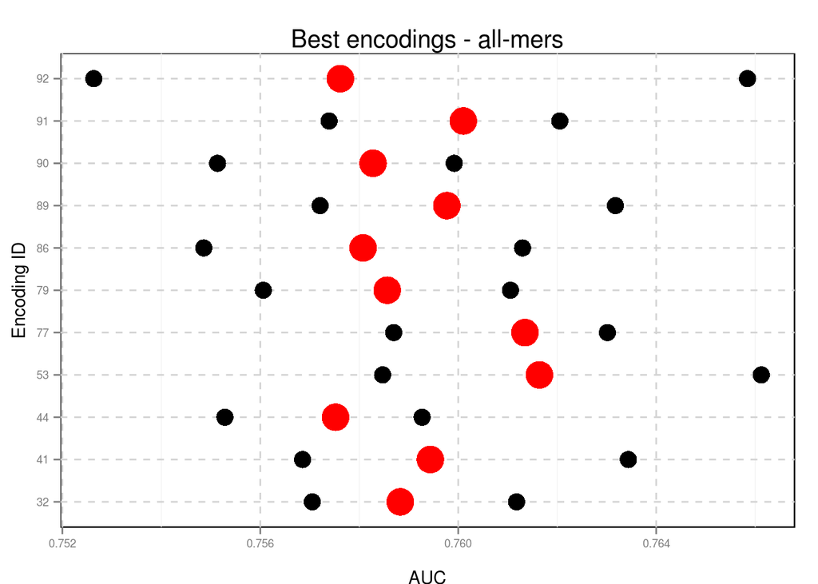

Kodowanie 32.

|  | Group |
| --- | --- |
| 1 | A, N, D, C, Q, E, G, P, S, T |
| 2 | R, H, K |
| 3 | I, L, M, F, W, Y, V |

Kodowanie 41.

|  | Group |
| --- | --- |
| 1 | A, N, D, C, Q, E, G, H, S, T |
| 2 | R, K |
| 3 | I, F, W, Y |
| 4 | L, M, P, V |

Kodowanie 44.

|  | Group |
| --- | --- |
| 1 | A, C, G, H, P |
| 2 | R, K |
| 3 | N, D, Q, E, S, T |
| 4 | I, L, M, F, W, Y, V |

Kodowanie 53.

|  | Group |
| --- | --- |
| 1 | A, N, D, C, Q, E, G, H, S, T |
| 2 | R, K |
| 3 | I, F, W, Y |
| 4 | L, M, P, V |

Kodowanie 77.

|  | Group |
| --- | --- |
| 1 | A, C, G |
| 2 | R, K |
| 3 | N, D, Q, E, H, S, T |
| 4 | I, F, W, Y |
| 5 | L, M, P, V |

Kodowanie 79.

|  | Group |
| --- | --- |
| 1 | A, G |
| 2 | R, K |
| 3 | N, D, Q, E, H, P, S, T |
| 4 | C, I, L, M, F, V |
| 5 | W, Y |

Kodowanie 86.

|  | Group |
| --- | --- |
| 1 | A, C, G |
| 2 | R, K |
| 3 | N, Q, H, P, S, T |
| 4 | D, E |
| 5 | I, L, M, F, W, Y, V |

Kodowanie 89.

|  | Group |
| --- | --- |
| 1 | A, C, G, S |
| 2 | R, K |
| 3 | N, D, Q, E, H, T |
| 4 | I, F, W, Y |
| 5 | L, M, P, V |

Kodowanie 90.

|  | Group |
| --- | --- |
| 1 | A, C |
| 2 | R, K |
| 3 | N, Q, E, H, P, T |
| 4 | D, G, S |
| 5 | I, L, M, F, W, Y, V |

Kodowanie 91.

|  | Group |
| --- | --- |
| 1 | A, G |
| 2 | R, K |
| 3 | N, D, Q, E, H, P, S, T |
| 4 | C, I, L, M, F, V |
| 5 | W, Y |

Kodowanie 92.

|  | Group |
| --- | --- |
| 1 | A, G, P |
| 2 | R, K |
| 3 | N, D, Q, E, S, T |
| 4 | C, H |
| 5 | I, L, M, F, W, Y, V |

Ponad połowa najlepszych kodowań zawiera 5 grup, pozostałe mniej.

Zliczenie cech wykorzystywanych przez najlepsze kodowania - parametr size.

|  | Property | Freq |
| --- | --- | --- |
| 1 | P30 Size (Dawson, 1972) In “The Biochemical Genetics of Man” (Brock, D.J.H. and Mayo, O., | 1 |
| 2 | P36 Molecular weight (Fasman, 1976) “Handbook of Biochemistry and Molecular Biology”, 3rd ed., Proteins - | 2 |
| 3 | P54 Volume (Grantham, 1974) Amino acid difference formula to help explain protein evolution Science 185, 862-864 (1974) | 8 |

Zliczenie cech wykorzystywanych przez najlepsze kodowania - parametr hydroph.

|  | Property | Freq |
| --- | --- | --- |
| 1 | P1 Hydrophobicity index (Argos et al., 1982) Structural prediction of membrane-bound proteins Eur. J. Biochem. 128, 565-575 (1982) | 4 |
| 2 | P26 Normalized average hydrophobicity scales (Cid et al., 1992) Hydrophobicity and structural classes in proteins Protein Engineering 5, 373-375 (1992) | 6 |
| 3 | P57 Hydrophilicity value (Hopp-Woods, 1981) Prediction of protein antigenic determinants from amino acid sequecces Proc. Natl. Acad. Sci. USA 78, 3824-3828 (1981) | 1 |

Zliczenie cech wykorzystywanych przez najlepsze kodowania - parametr solvent.

|  | Property | Freq |
| --- | --- | --- |
| 1 | P199 Hydration potential (Wolfenden et al., 1981) Affinties of amino acid side chains for solvent water Biochemistry 20, 849-855 (1981) | 1 |
| 2 | P19 Residue accessible surface area in folded protein (Chothia, 1976) The nature of the accessible and buried surfaces in proteins J. Mol. Biol. 105, 1-14 (1976) | 5 |
| 3 | P65 Average accessible surface area (Janin et al., 1978) Conformation of amino acid side-chains in proteins J. Mol. Biol. 125, 357-386 (1978) | 5 |

# Porównanie najlepszych kodowań

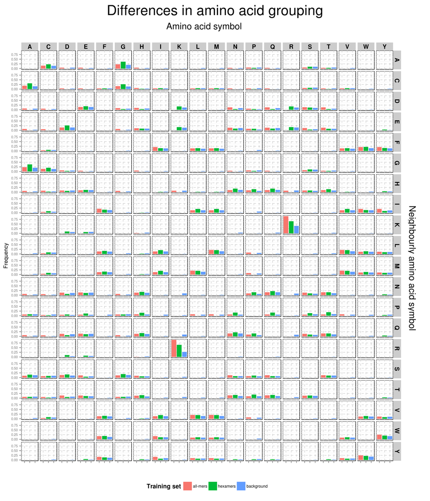

Rysunek powyżej przedstawia różnice w grupowaniu aminokwasów dla najlepszych grupowań. Wysokość słupka odpowiada częstotliwości z jaką aminokwas $a_1$ był zaliczany do tej samej grupy, co aminokwas $a_2$. Grupa “background” oznacza wszystkie możliwe kodowania.

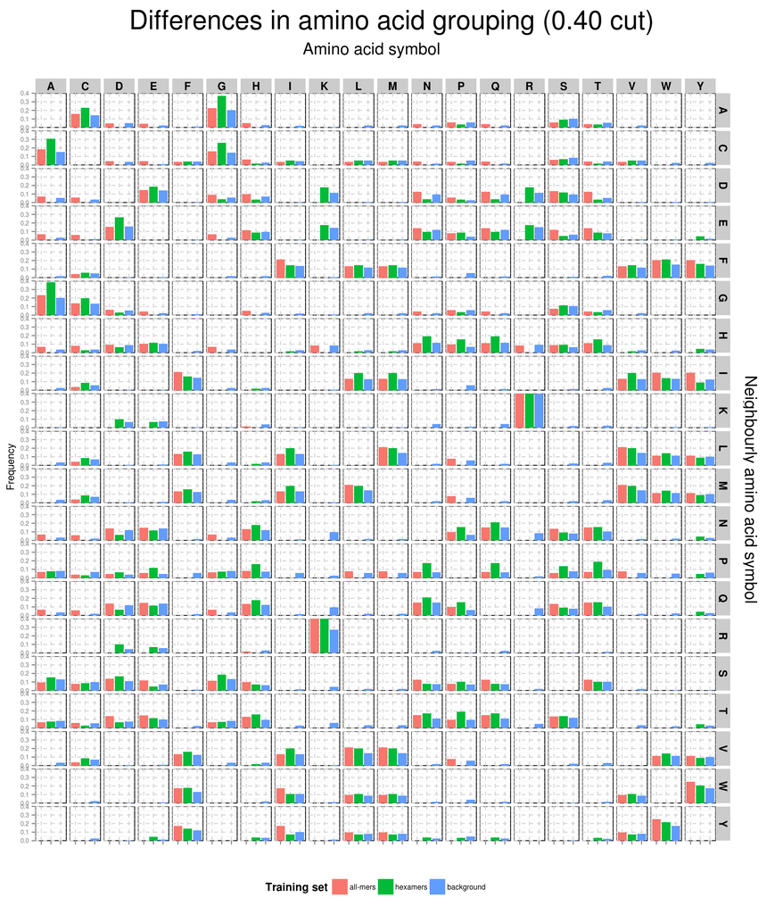

Ten sam wykres, co powyżej. Z uwagi na to, że arginina i lizyna występują razem bardzo często utrudniając obserwację zmienności dla innych par aminokwasów, wszystkie wykresy przycięto do wartości częstości 0.40.